# Мастер-класс по анализу данных решений арбитражных судов в R

Алексей Кнорре

4 марта 2017

# Начало

Эту презентацию, код и данные можно найти здесь: https://github.com/alexeyknorre/Rbitrazh  
или здесь:  
https://clck.ru/Afiti

# О себе

Социолог в Институте проблем правоприменения при ЕУСПб.  
Занимаюсь анализом данных криминальной статистики, например, [наркотиками](http://enforce.spb.ru/images/analit_zapiski/FSKN_MVD_memo_2015_web.pdf) и [убийствами](http://www.vedomosti.ru/opinion/articles/2016/11/03/663453-podschet-ubiistv).

# Данные решений арбитражных судов

10893 закодированных решения с сайтов арбитражных судов. Случайная выборка из 5 млн. дел за 2007-2011 годы.  
Данные в открытом виде [доступны на Dataverse](https://dataverse.harvard.edu/dataverse/irl_data).  
По ссылке есть инструкция для вводчиков/кодбук, 80 переменных.  
Данные использовались для нескольких статей и аналитических записок, наиболее полный отчёт по исследованию этих данных [здесь](http://enforce.spb.ru/images/analit_zapiski/irl_arbitrazh_site_new.pdf).

# О чём мастер-класс?

- *Начальные приёмы рукопашного боя с данными*
- Пакеты ggplot2 и dplyr для анализа данных
- Визуализация, логарифмирование переменной и подготовка/группировка данных
- Репликация результатов (“копеечные дела”)

# Используемые переменные

- **dec_sum** - сумма иска
- **date_…** - даты принятия иска, первого суда и решения суда
- **dec_type** - кто заявитель?
- **pair** - производная переменная, показывающая, кто заявитель (гос.орган или предприниматель) и истец (4 возможных значения)
- **regi** - регион, в котором рассматривалось дело

# На какие вопросы будем отвечать:

- Что можно сказать о сумме иска в арбитражных делах? От чего зависит сумма иска?
- Как долго рассматривается дело судом? От чего это может зависеть? Где и с кем дела рассматриваются быстрее, а где медленнее?
- Связаны ли сумма иска и длительность рассмотрения?

# к делу

Подгружаем библиотеки и данные:

```r
library(ggplot2)
library(dplyr)
library(scales)


commercial_courts_cases <- read.csv("https://github.com/alexeyknorre/Rbitrazh/raw/master/IRL_commcourts_decisions_cp1251.csv",
          stringsAsFactors = FALSE)
attach(commercial_courts_cases)
```

# Базовая описательная статистика для суммы иска

```r
summary(sum_dec)
```

```
##      Min.   1st Qu.    Median      Mean   3rd Qu.      Max.      NA's
## 2.000e+00 7.018e+03 5.318e+04 2.517e+06 3.123e+05 2.425e+09      2610
```

# Попробуем гистограмму

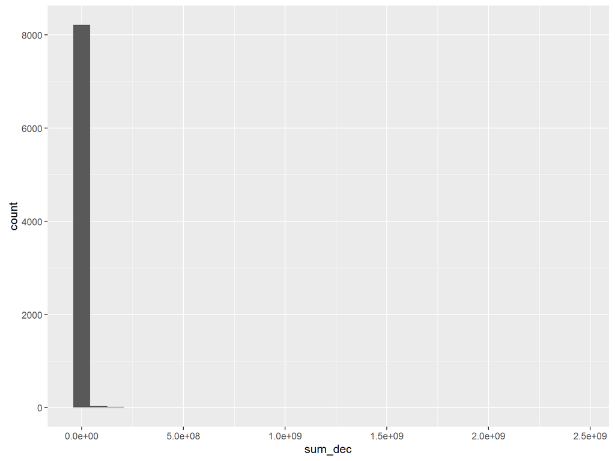

```r
qplot(sum_dec)
```